# Data Train | OT-SC-WS-04: Evaluating machine learning and artificial intelligence algorithms

Max Westphal (max.westphal@mevis.fraunhofer.de)

# R session 2: Experimental design in ML performance evaluation

```r
## clear enviroment:
rm(list = ls())

## calc_costly determines if computationally expensive steps should be run during notebook rendering:
calc_costly <- FALSE

## save_vars determines if certain intermediate variables should be saved during notebook rendering:
save_vars <- FALSE
```

```r
library(dplyr)
library(mlr3verse)
```

## Exercise 1: Task preparation (15 minutes)

Today, we work with the **Cardiotocography Data Set** from the **UCI Machine Learning Repository**. Let’s import a preprocessed version of the data set.

```r
ctg_data <- readRDS("data/session2/ctg_data.rds")
dim(ctg_data)
```

```
## [1] 2126   25
```

```r
head(ctg_data)
```

|  | status | Date | LBE | LB | AC | FM | UC | ASTV | MSTV | ALTV | MLTV | DL | DS | DP | DR | Width | Min | Max | Nmax | Nzeros | Mode | Mean | Median | Variance | Tendency |
| --- | --- | --- | --- | --- | --- | --- | --- | --- | --- | --- | --- | --- | --- | --- | --- | --- | --- | --- | --- | --- | --- | --- | --- | --- | --- |
| 1 | suspect | 1980-01-04 | 159 | 159 | 0 | 0 | 4 | 65 | 0.4 | 16 | 10.8 | 0 | 0 | 0 | 0 | 91 | 81 | 172 | 0 | 0 | 163 | 163 | 165 | 2 | 1 |
| 2 | suspect | 1980-01-04 | 159 | 159 | 0 | 0 | 3 | 69 | 0.3 | 21 | 6.4 | 0 | 0 | 0 | 0 | 15 | 153 | 168 | 0 | 0 | 163 | 163 | 164 | 0 | 1 |
| 3 | suspect | 1980-01-04 | 159 | 159 | 0 | 0 | 2 | 62 | 0.5 | 6 | 13.2 | 0 | 0 | 0 | 0 | 91 | 81 | 172 | 0 | 0 | 163 | 163 | 164 | 2 | 1 |
| 4 | suspect | 1980-01-04 | 159 | 159 | 0 | 0 | 2 | 65 | 0.4 | 11 | 6.8 | 0 | 0 | 0 | 0 | 15 | 153 | 168 | 0 | 0 | 163 | 162 | 164 | 0 | 1 |
| 5 | normal | 1980-01-04 | 158 | 158 | 0 | 0 | 0 | 54 | 0.6 | 34 | 8.0 | 0 | 0 | 0 | 0 | 93 | 77 | 170 | 3 | 0 | 165 | 163 | 165 | 2 | 1 |
| 6 | normal | 1980-01-04 | 158 | 158 | 0 | 0 | 0 | 55 | 0.5 | 38 | 5.8 | 0 | 0 | 0 | 0 | 15 | 156 | 171 | 0 | 0 | 165 | 164 | 166 | 0 | 0 |

A basic documentation and the original data is provided at https://archive.ics.uci.edu/ml/datasets/cardiotocography. There, it is stated that

> 2126 fetal cardiotocograms (CTGs) were automatically processed and the respective diagnostic features measured. The CTGs were also classified by three expert obstetricians and a consensus classification label assigned to each of them. Classification was both with respect to a morphologic pattern (A, B, C. …) and to a fetal state (N, S, P). Therefore the dataset can be used either for 10-class or 3-class experiments

We actually have a simplified version of the task with a binary target `status` with two states `"suspect"`(positive class, including the original `"pathological"` state) and `"normal"`. In addition, a few unneeded columns have been removed from the original data set.

```r
summary(ctg_data$status)
```

```
##  normal suspect
##    1655     471
```

Note: The data set has a `Date` variable, i.e. each observation has a time stamp, which is rare for public data sets. The observations are actually sorted according to `Date`. We will make use of this feature throughout this exercise.

```r
summary(ctg_data$Date)
```

```
##                  Min.               1st Qu.                Median
## "1980-01-04 00:00:00" "1996-05-02 00:00:00" "1996-08-21 00:00:00"
##                  Mean               3rd Qu.                  Max.
## "1996-04-22 17:17:56" "1997-03-20 00:00:00" "1998-06-06 00:00:00"
```

```r
table(substr(ctg_data$Date, 1, 4))
```

```
##
## 1980 1995 1996 1997 1998
##   56  313 1174  330  253
```

The number of observations makes clear that we (strangely) have 56 observations from 1980, a very small number compared to the remaining observations from the years 1995-1998. One may reasonable suspect that these observations will be quite distinct from the rest (or a coding error). Anyhow, we will remove the observations from the data set for our purposes.

**Task: reduce `ctg_data` to only include observations from the year 1995-1998.**

```r
ctg_data <- ctg_data %>% filter(substr(ctg_data$Date, 1, 4) != "1980")
table(substr(ctg_data$Date, 1, 4))
```

```
##
## 1995 1996 1997 1998
##  313 1174  330  253
```

Let’s define the `mlr3` ML task for today:

```r
ctg_task <- as_task_classif(ctg_data %>% select(-Date),
                            target = "status",
                            positive = "suspect",
                            id = "ctg_task")
ctg_task
```

```
## <TaskClassif:ctg_task> (2070 x 24)
## * Target: status
## * Properties: twoclass
## * Features (23):
##   - dbl (23): AC, ALTV, ASTV, DL, DP, DR, DS, FM, LB, LBE, MLTV, MSTV,
##     Max, Mean, Median, Min, Mode, Nmax, Nzeros, Tendency, UC, Variance,
##     Width
```

**Question: Why do we want exclude the `Date` variable from the feature set for modeling purposes?**

- A predictive model would be required to extrapolate (widely) for new, unseen data (with newer `Date` than those in `ctg_data)` which may lead to biased results

By the way, we will not cut of a distinct test set today (compared to session 1). The main reason is simplicity. If this was a real-life study, an additional evaluation on a distinct test data set might be needed, depending on the context.

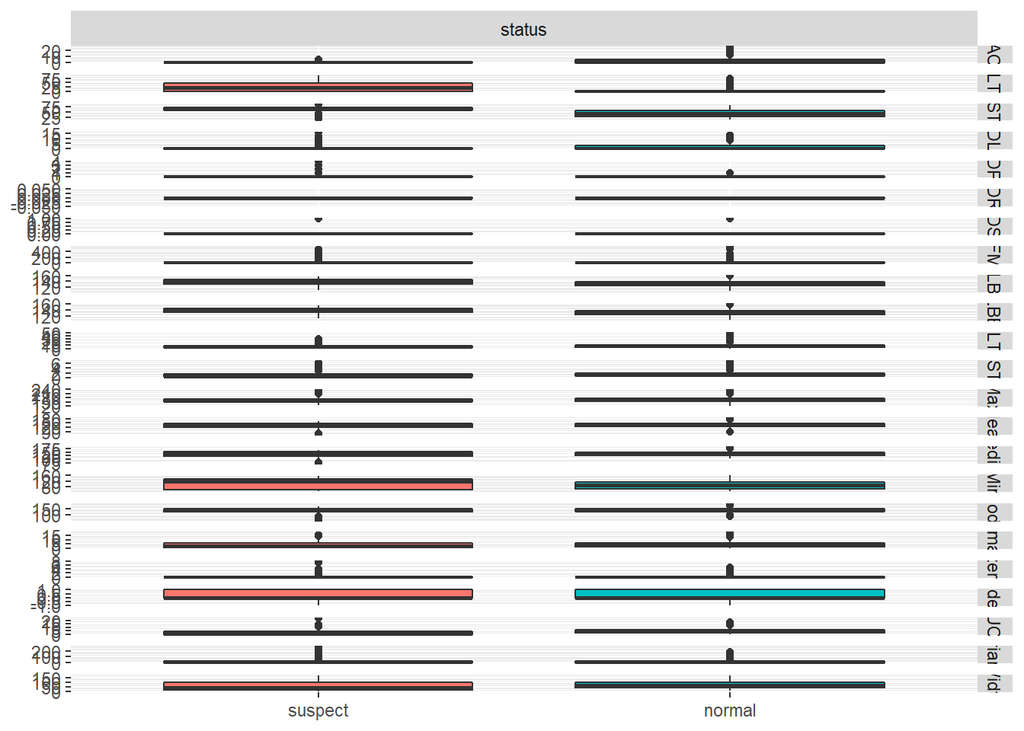

```r
autoplot(ctg_task, type="duo")
```

## Exercise 2: Common CV variants (15 minutes)

The focus in the following will be in defining different experimental designs and observing and interpreting the different results. We would not do this in an actual ML project but rather decide in advance which experimental design suits the context of our study best, e.g. is best aligned with our study goals and/or deployment scenarios.

### Cross-validation (10-fold)

We start by defining a very standard design, namely 10-fold CV.

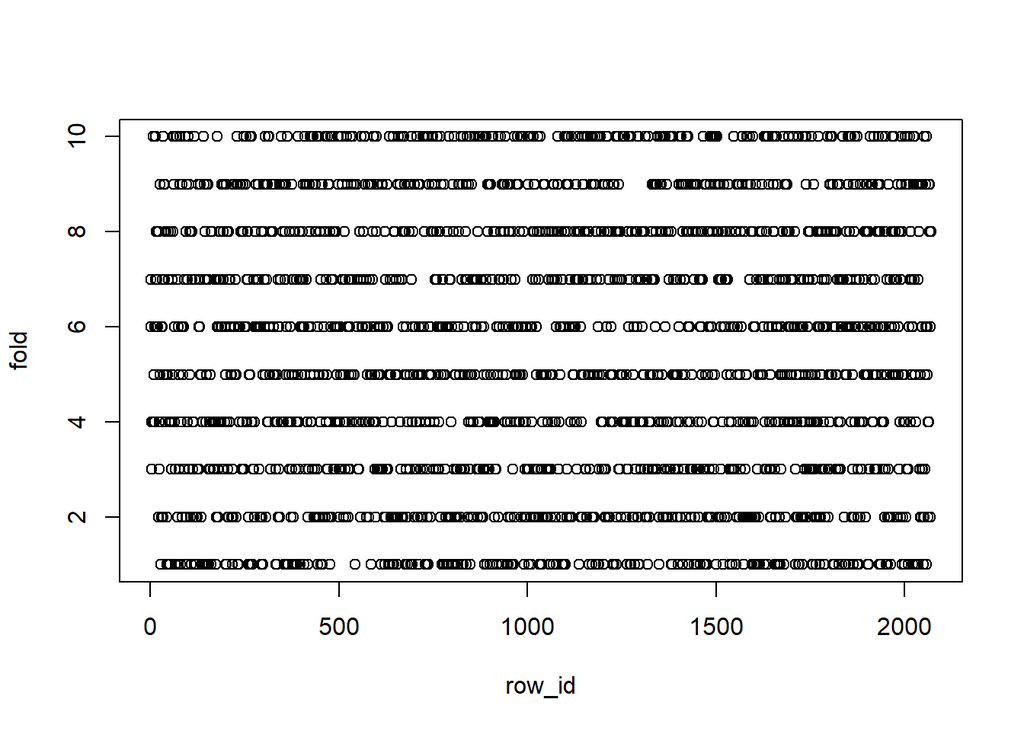

```r
set.seed(1337)
exp_design_a <- rsmp("cv")
exp_design_a$instantiate(ctg_task)
exp_design_a$instance %>% plot()
```

### Cross-validation (5-fold)

**Task: define `exp_design_b` as 5-fold CV.**

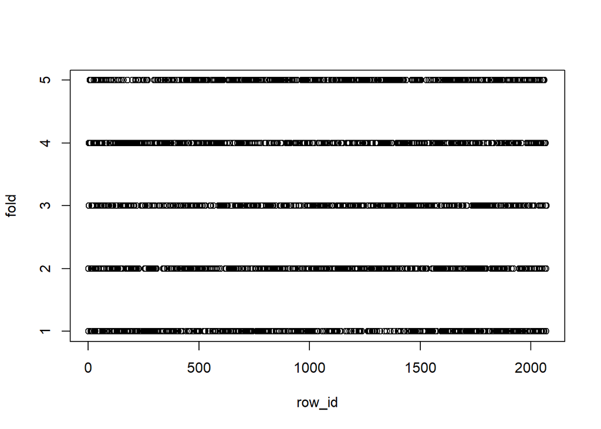

```r
set.seed(1337)
exp_design_b <- rsmp("cv", folds=5)
exp_design_b$instantiate(ctg_task)
exp_design_b$instance %>% plot()
```

### Repeated cross-validation (5-fold, 4 repeats)

**Task: define `exp_design_c` as repeated CV with 5 folds and 4 repetitions.**

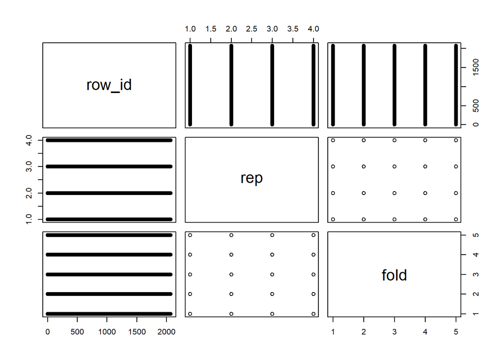

```r
set.seed(1337)
exp_design_c <- rsmp("repeated_cv", folds=5, repeats=4)
exp_design_c$instantiate(ctg_task)
exp_design_c$instance %>% plot()
```

## Exercise 3: Custom experimental designs (15 minutes)

We have removed the `Date` variable for modeling purposes but we want to employ it to define custom experimental designs in the following.

**Task: create a copy `ctg_data_ext` of `ctg_data` with one additional variable showing the year component of `Date`**.

```r
ctg_data_ext <- ctg_data %>% mutate(Year = substr(Date, 1, 4))
table(ctg_data_ext$Year)
```

```
##
## 1995 1996 1997 1998
##  313 1174  330  253
```

### Cross-validation (grouped by year)

Usual (random) cross-validation assumes a homogeneous data sample and assesses generalization to new (unseen) samples. We might suspect that patient characteristics change over time. Thus, for the next, experimental design we want to access how models generalize to different years (unseen during training). Have a close look at the (special) syntax, you might need it quite soon.

```r
exp_design_d <- rsmp("custom_cv")
exp_design_d$instantiate(ctg_task, f=as.factor(ctg_data_ext$Year))
exp_design_d$instance %>% str()
```

```
## List of 4
##  $ 1995: int [1:313] 1 2 3 4 5 6 7 8 9 10 ...
##  $ 1996: int [1:1174] 314 315 316 317 318 319 320 321 322 323 ...
##  $ 1997: int [1:330] 1488 1489 1490 1491 1492 1493 1494 1495 1496 1497 ...
##  $ 1998: int [1:253] 1818 1819 1820 1821 1822 1823 1824 1825 1826 1827 ...
```

### Custom design “train 1, predict 1”

Now we want to define a `"custom"` design, where data from one year is used for training and assessed on unseen data from the following year.

```r
rsmp("custom")
```

```
## <ResamplingCustom> with NA iterations
## * Instantiated: FALSE
## * Parameters: list()
```

```r
unique(ctg_data_ext$Year)
```

```
## [1] "1995" "1996" "1997" "1998"
```

**Task: define two lists`train_sets_e` and `test_sets_e` . Both lists should have length 3. (Why?) Each element is a vector of row indies defining train and test sets as indicated above.**

(Hint: you need to incorporate the variable `ctg_data_ext$Year` )

```r
train_sets_e <- list(
  which(ctg_data_ext$Year == "1995"),
  which(ctg_data_ext$Year == "1996"),
  which(ctg_data_ext$Year == "1997")
)
test_sets_e <- list(
  which(ctg_data_ext$Year == "1996"),
  which(ctg_data_ext$Year == "1997"),
  which(ctg_data_ext$Year == "1998")
)
```

```r
exp_design_e <- rsmp("custom")
exp_design_e$instantiate(ctg_task,
                         train_sets = train_sets_e,
                         test_sets = test_sets_e)
exp_design_e$instance %>% str()
```

```
## List of 2
##  $ train:List of 3
##   ..$ : int [1:313] 1 2 3 4 5 6 7 8 9 10 ...
##   ..$ : int [1:1174] 314 315 316 317 318 319 320 321 322 323 ...
##   ..$ : int [1:330] 1488 1489 1490 1491 1492 1493 1494 1495 1496 1497 ...
##  $ test :List of 3
##   ..$ : int [1:1174] 314 315 316 317 318 319 320 321 322 323 ...
##   ..$ : int [1:330] 1488 1489 1490 1491 1492 1493 1494 1495 1496 1497 ...
##   ..$ : int [1:253] 1818 1819 1820 1821 1822 1823 1824 1825 1826 1827 ...
```

### Custom design “train 2, predict 1”

**Task: define two lists`train_sets_f` and `test_sets_f` . Both lists should have length 2. (Why?) Each element is a vector of row indies defining train and test sets as indicated above.**

```r
train_sets_f <- list(
  which(ctg_data_ext$Year %in% c("1995", "1996")),
  which(ctg_data_ext$Year %in% c("1996", "1997"))
)
test_sets_f <- list(
  which(ctg_data_ext$Year == "1997"),
  which(ctg_data_ext$Year == "1998")
)
```

```r
exp_design_f <- rsmp("custom")
exp_design_f$instantiate(ctg_task,
                         train_sets = train_sets_f,
                         test_sets = test_sets_f)
exp_design_f$instance %>% str()
```

```
## List of 2
##  $ train:List of 2
##   ..$ : int [1:1487] 1 2 3 4 5 6 7 8 9 10 ...
##   ..$ : int [1:1504] 314 315 316 317 318 319 320 321 322 323 ...
##  $ test :List of 2
##   ..$ : int [1:330] 1488 1489 1490 1491 1492 1493 1494 1495 1496 1497 ...
##   ..$ : int [1:253] 1818 1819 1820 1821 1822 1823 1824 1825 1826 1827 ...
```

## Exercise 4: Model tuning (10 minutes)

Now that we defined all these different experimental design (training/validation splits), lets compare the benchmark results.

Today, we’ll be employing a famous and very powerful algorithm extreme gradient boosting (XGBoost). This will get computationally intensive, at least much more than before. We can use the parallelization capabilities of `mlr3` to reduce the run time of our benchmark experiment.

**Note: The code blocks below (`xgb_learner_tuned_xyz <- tune(…)` ) may take a long time to run. We have pre-computed the results for you. They will be loaded at the start of the next section. Make sure that you understand what’s happening in the next code chunks even if you don’t run them.**

```r
future::availableCores()
```

```
## system
##     32
```

```r
num_threads <- round(0.8*future::availableCores())
# num_threads <- 1 # when working on RStudio Server
```

```r
future::plan("multisession")
```

To get a reasonable default hyperparameter tuning space we make use of the `mlr3tuningspaces` package.

```r
ts <- mlr3tuningspaces::lts("classif.xgboost.default")
xgb_learner <- ts$get_learner()
xgb_learner$predict_type <- "prob"
set_threads(xgb_learner, n = num_threads)
```

```
## <LearnerClassifXgboost:classif.xgboost>
## * Model: -
## * Parameters: nrounds=<RangeTuneToken>, nthread=26, verbose=0,
##   eta=<RangeTuneToken>, max_depth=<RangeTuneToken>,
##   colsample_bytree=<RangeTuneToken>,
##   colsample_bylevel=<RangeTuneToken>, lambda=<RangeTuneToken>,
##   gamma=<RangeTuneToken>, alpha=<RangeTuneToken>,
##   subsample=<RangeTuneToken>
## * Packages: xgboost
## * Predict Type: prob
## * Feature types: logical, integer, numeric
## * Properties: importance, missings, multiclass, twoclass, weights
```

```r
xgb_learner
```

```
## <LearnerClassifXgboost:classif.xgboost>
## * Model: -
## * Parameters: nrounds=<RangeTuneToken>, nthread=26, verbose=0,
##   eta=<RangeTuneToken>, max_depth=<RangeTuneToken>,
##   colsample_bytree=<RangeTuneToken>,
##   colsample_bylevel=<RangeTuneToken>, lambda=<RangeTuneToken>,
##   gamma=<RangeTuneToken>, alpha=<RangeTuneToken>,
##   subsample=<RangeTuneToken>
## * Packages: xgboost
## * Predict Type: prob
## * Feature types: logical, integer, numeric
## * Properties: importance, missings, multiclass, twoclass, weights
```

Lets sample 40 hyperparameters from this space now.

```r
set.seed(1337)
num_hp <- 40
xgb_space <- xgb_learner$param_set$search_space()
xgb_hp <- generate_design_lhs(xgb_space, num_hp)
xgb_hp
```

```
## <Design> with 40 rows:
##     nrounds        eta max_depth colsample_bytree colsample_bylevel    lambda
##  1:    2333 -5.3762966        20        0.1978505         0.4053580 0.8258163
##  2:     874 -5.2172338        13        0.6520415         0.7847124 0.4606199
##  3:    3367 -6.3490589        10        0.7482993         0.3539160 0.2283477
##  4:    1545 -0.3315345         2        0.2458011         0.5092319 0.9653738
##  5:    1742 -3.5280813         8        0.3337803         0.3434203 0.4832326
##  6:    3169 -2.3808469        11        0.4119617         0.8616899 0.5914428
##  7:    3445 -4.5029757         7        0.3727584         0.1152538 0.3575815
##  8:    1766 -5.7395690        13        0.7194211         0.7267606 0.2713992
##  9:    1065 -1.3256281        16        0.2759238         0.6085220 0.3872405
## 10:    2529 -9.1601576        19        0.8802998         0.8000957 0.3181329
## 11:    2780 -3.3197923        15        0.8335528         0.8748380 0.6257534
## 12:    3528 -7.2383267        14        0.5369258         0.6596230 0.5229156
## 13:    3021 -2.1019856         4        0.9119355         0.2975141 0.7315874
```

[output cut: 70 more lines]

**Question: What is the function `generate_design_lhs` doing?**

- See `?generate_design_lhs` and also https://en.wikipedia.org/wiki/Latin_hypercube_sampling

```r
if(save_vars){
  saveRDS(xgb_hp, "data/session2/xgb_hp.rds")
}
xgb_hp <- readRDS("data/session2/xgb_hp.rds")
```

```r
set.seed(1337)
xgb_learner_tuned_a <- mlr3tuning::tune(
  method = "design_points",
  task = ctg_task,
  learner = xgb_learner,
  resampling = exp_design_a,
  measures = msrs(c("classif.auc")),
  design = xgb_hp$data,
  batch_size = num_threads
)
```

```r
set.seed(1337)
xgb_learner_tuned_b <- mlr3tuning::tune(
  method = "design_points",
  task = ctg_task,
  learner = xgb_learner,
  resampling = exp_design_b,
  measures = msrs(c("classif.auc")),
  design = xgb_hp$data,
  batch_size = num_threads
)
```

```r
set.seed(1337)
xgb_learner_tuned_c <- mlr3tuning::tune(
  method = "design_points",
  task = ctg_task,
  learner = xgb_learner,
  resampling = exp_design_c,
  measures = msrs(c("classif.auc")),
  design = xgb_hp$data,
  batch_size = num_threads
)
```

```r
set.seed(1337)
xgb_learner_tuned_d <- mlr3tuning::tune(
  method = "design_points",
  task = ctg_task,
  learner = xgb_learner,
  resampling = exp_design_d,
  measures = msrs(c("classif.auc")),
  design = xgb_hp$data,
  batch_size = num_threads
)
```

```r
set.seed(1337)
xgb_learner_tuned_e <- mlr3tuning::tune(
  method = "design_points",
  task = ctg_task,
  learner = xgb_learner,
  resampling = exp_design_e,
  measures = msrs(c("classif.auc")),
  design = xgb_hp$data,
  batch_size = num_threads
)
```

```r
set.seed(1337)
xgb_learner_tuned_f <- mlr3tuning::tune(
  method = "design_points",
  task = ctg_task,
  learner = xgb_learner,
  resampling = exp_design_f,
  measures = msrs(c("classif.auc")),
  design = xgb_hp$data,
  batch_size = num_threads
)
```

```r
xgb_learner_tuned_all <- list(xgb_learner_tuned_a,
                              xgb_learner_tuned_b,
                              xgb_learner_tuned_c,
                              xgb_learner_tuned_d,
                              xgb_learner_tuned_e,
                              xgb_learner_tuned_f)
xgb_lta_archives <-
  lapply(xgb_learner_tuned_all, function(x) as.data.table(x$archive))
names(xgb_lta_archives) <- letters[1:6]
```

## Exercise 5: Comparison of evaluation results based on different designs (20 minutes)

In this section, we start the (most important) interpretation part. Recall that, so far, we have used six different experimental setup on the same ML task. Now, we will have a look at how these different designs affect our evaluation results.

Let’s have a look at the archives attribute from all benchmark results. Load the pre-computed results unless you were brave enough to run the training/tuning chunks yourself.

```r
if(save_vars){
  saveRDS(xgb_lta_archives, "data/session2/xgb_lta_archives.rds")
}
xgb_lta_archives <- readRDS("data/session2/xgb_lta_archives.rds")
```

```r
str(xgb_lta_archives, 1)
```

```
## List of 6
##  $ a:Classes 'data.table' and 'data.frame':  40 obs. of  23 variables:
##   ..- attr(*, ".internal.selfref")=<externalptr>
##  $ b:Classes 'data.table' and 'data.frame':  40 obs. of  23 variables:
##   ..- attr(*, ".internal.selfref")=<externalptr>
##  $ c:Classes 'data.table' and 'data.frame':  40 obs. of  23 variables:
##   ..- attr(*, ".internal.selfref")=<externalptr>
##  $ d:Classes 'data.table' and 'data.frame':  40 obs. of  23 variables:
##   ..- attr(*, ".internal.selfref")=<externalptr>
##  $ e:Classes 'data.table' and 'data.frame':  40 obs. of  23 variables:
##   ..- attr(*, ".internal.selfref")=<externalptr>
##  $ f:Classes 'data.table' and 'data.frame':  40 obs. of  23 variables:
##   ..- attr(*, ".internal.selfref")=<externalptr>
```

Of course, we are most interested in the AUCs.

```r
xgb_lta_aucs <- sapply(xgb_lta_archives, function(x) x$classif.auc) %>% as.data.table()
head(xgb_lta_aucs)
```

| a | b | c | d | e | f |
| --- | --- | --- | --- | --- | --- |
| 0.9802052 | 0.9802581 | 0.9808614 | 0.9556135 | 0.9175748 | 0.9358437 |
| 0.9833679 | 0.9830756 | 0.9837670 | 0.9538292 | 0.9256202 | 0.9136864 |
| 0.9669092 | 0.9640791 | 0.9660989 | 0.9392554 | 0.8947321 | 0.8826665 |
| 0.9837917 | 0.9830667 | 0.9807497 | 0.9422246 | 0.9318927 | 0.9219640 |
| 0.9870197 | 0.9873345 | 0.9874135 | 0.9605099 | 0.9446471 | 0.9425140 |
| 0.9445312 | 0.9407494 | 0.9433401 | 0.9053345 | 0.6884855 | 0.7709184 |

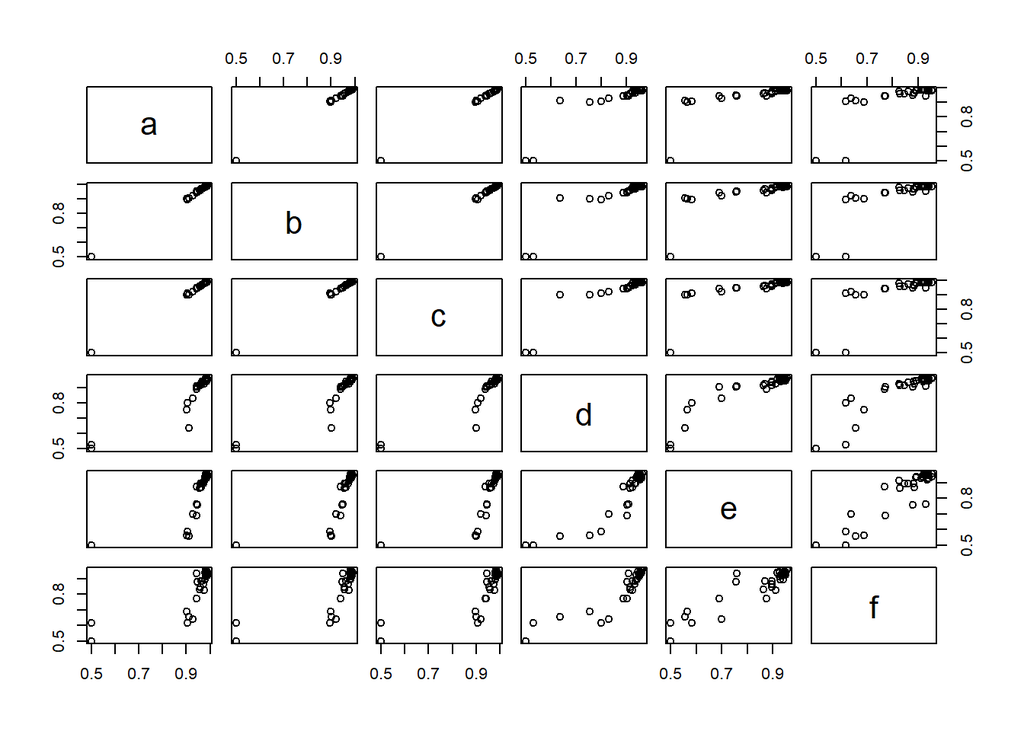

```r
pairs(xgb_lta_aucs)
```

**Question: How can the pairs plot be interpreted?**

- One dot represents one hyperparameter combination and its performance under different experimental design. While everything is positively correlated, we can the the systematic differences due to the different experimental designs. In particular design A-C are much more strongly correlated compared to the other designs.

**Task: Estimate and interpret the correlation matrix of the `aucs` object.**

```r
cov(xgb_lta_aucs) %>% cov2cor()
```

```
##           a         b         c         d         e         f
## a 1.0000000 0.9998996 0.9999172 0.9690808 0.8778069 0.9079517
## b 0.9998996 1.0000000 0.9999342 0.9715511 0.8822275 0.9128074
## c 0.9999172 0.9999342 1.0000000 0.9713210 0.8806966 0.9110627
## d 0.9690808 0.9715511 0.9713210 1.0000000 0.9457703 0.9585704
## e 0.8778069 0.8822275 0.8806966 0.9457703 1.0000000 0.9540914
## f 0.9079517 0.9128074 0.9110627 0.9585704 0.9540914 1.0000000
```

**Task: For each experimental design, find the hyperparameter configuration which maximizes the AUC and save the index in the vector `best`.**

```r
apply(xgb_lta_aucs, 2, max)
```

```
##         a         b         c         d         e         f
## 0.9893334 0.9900332 0.9895943 0.9653070 0.9562787 0.9552680
```

```r
best <- apply(xgb_lta_aucs, 2, which.max)
best
```

```
##  a  b  c  d  e  f
## 35 35 35 32 32 32
```

Let’s have a look at the corresponding hyperparameters.

```r
xgb_hp$data[unique(best), ]
```

| nrounds | eta | max_depth | colsample_bytree | colsample_bylevel | lambda | gamma | alpha | subsample |
| --- | --- | --- | --- | --- | --- | --- | --- | --- |
| 605 | -3.716921 | 19 | 0.6962886 | 0.2215778 | 0.1006946 | -5.285248 | -6.342576 | -0.7318381 |
| 1367 | -2.559580 | 1 | 0.2216714 | 0.5480618 | 0.6451472 | -7.392153 | -6.861954 | -0.4260412 |

**Task: Fill in the following table, describing the context and resources (no R code required, only common sense). Which design(s) are most appropriate?**

|  | Experimental design | R esources (training runs per HP) | Context (what are we estimating?) | R easonable design? |
| --- | --- | --- | --- | --- |
| A | 10-fold CV | 10 | expected AUC when training models based on 90% of sample size | probably not |
| B | 5- fold CV | 5 | expected AUC when training models based on 80% of sample size | probably not |
| C | 5-fold CV (4 repetitions) | 20 | expected AUC when training models based on 80% of sample size | probably not |
| D | custom block design (years) | 4 | expected AUC when training models based on various fractions of sample size from different years | probably not |
| E | custom design “train 1, predict 1” | 3 | expected AUC when training models based on samples from past year | maybe |
| F | custom design “train 2, predict 1” | 2 | expected AUC when training models based on samples from past two years | maybe |

**Question: For design D, E and F, do the different sample sizes over the years pose a problem?**

- Sort of. The performances differences can not be attributed solely to the different time periods used for training and prediction.

**Question: Can you think of other relevant custom design for this specific task?**

- A remedy for the issue mentioned above might be to not split based on calendar years but rather based on time such that all time windows have an equal number of observations.

## Exercise 6: Nested CV including inference (30 minutes)

The goal for this exercise will be to conduct statistical inference for a more complex experimental design, namely nested cross-validation. First, let’s have a look at the documentation of the `tune_nested` function.

```r
?tune_nested
```

```r
set.seed(1337)
xgb_learner_tuned_nested <- mlr3tuning::tune_nested(
  method = "random_search",
  task = ctg_task,
  learner = xgb_learner,
  inner_resampling = rsmp("holdout", ratio=0.8),
  outer_resampling = rsmp("cv", folds = 5),
  measure = msr("classif.auc"),
  term_evals = 40,
  batch_size = num_threads
)
xgb_ltn_preds <- as.data.table(xgb_learner_tuned_nested$prediction())
xgb_ltn_resamp <- xgb_learner_tuned_nested$resampling$instance
```

```r
if(save_vars){
  saveRDS(xgb_ltn_preds, "data/session2/xgb_ltn_preds.rds")
  saveRDS(xgb_ltn_resamp, "data/session2/xgb_ltn_resamp.rds")
}
xgb_ltn_preds <- readRDS("data/session2/xgb_ltn_preds.rds")
xgb_ltn_resamp <- readRDS("data/session2/xgb_ltn_resamp.rds")
```

Let’s have a look at parts of the object.

```r
xgb_ltn_preds
```

| row_ids | truth | response | prob.suspect | prob.normal |
| --- | --- | --- | --- | --- |
| 1 | normal | normal | 2.596096e-04 | 0.9997403904 |
| 12 | suspect | suspect | 7.229379e-01 | 0.2770621181 |
| 16 | normal | normal | 1.957054e-02 | 0.9804294631 |
| 20 | suspect | normal | 4.258651e-03 | 0.9957413487 |
| 27 | normal | normal | 2.332613e-03 | 0.9976673867 |
| 28 | normal | normal | 3.211643e-03 | 0.9967883569 |
| 29 | normal | normal | 5.962481e-03 | 0.9940375187 |
| 31 | normal | normal | 1.091713e-03 | 0.9989082875 |
| 43 | normal | normal | 8.512414e-03 | 0.9914875859 |
| 46 | normal | normal | 4.013778e-03 | 0.9959862218 |

[output cut: 2060 more lines]

```r
xgb_ltn_resamp
```

| row_id | fold |
| --- | --- |
| 1 | 1 |
| 12 | 1 |
| 16 | 1 |
| 20 | 1 |
| 27 | 1 |
| 28 | 1 |
| 29 | 1 |
| 31 | 1 |
| 43 | 1 |
| 46 | 1 |

[output cut: 2060 more lines]

Finally, let’s utilize the `ci.cvAUC` function from the `cvAUC` package to estimate the final AUC (outer CV loop) and also calculate a confidence interval.

```r
library(cvAUC)
```

```r
?ci.cvAUC
```

**Task: apply the `ci.cvAUC` function to calculate confidence intervals for the final AUC.**

```r
ci.cvAUC(
  predictions = xgb_ltn_preds$prob.suspect,
  labels = xgb_ltn_preds$truth,
  folds = xgb_ltn_resamp %>% arrange(row_id) %>% {as.integer(.$fold)}
)
```

```
## $cvAUC
## [1] 0.9874083
##
## $se
## [1] 0.002282233
##
## $ci
## [1] 0.9829352 0.9918814
##
## $confidence
## [1] 0.95
```

**Question: what is the advantage of nested CV (as conducted above) compared to usual 5-fold CV (as defined earlier in experimental design B)?**

- Reduced bias for the outer loop AUC estimate because model selection (inner loop) and performance estimation are now clearly separated in contrast to conventional CV (both based on outer/only loop).

**Question: For what quantity have we just calculated an estimate and confidence interval?**

- The expected AUC of models trained via the XGBoost algorithm (applied to 80% of the data set size, i.e. 1656 observations) whereby the hyperparameter have been optimized in the inner CV loop via random search. (Keep in mind that our target population is from years 1995 to 1998 and )

**Question: Connecting these results to exercise 5, how relevant is our nested CV result from a practical viewpoint? Can the relevance be improved?**

- Probably more relevant custom nested CV variant would be to define outer and inner loop based on the Date variable, i.e. in both loops use earlier samples for training and later samples for prediction.

**Question: If we wanted to implement a trained predictive model in (clinical) practice - what would we need to do?**

- Apply the XGBoost algorithm with the ‘winning’ hyperparameter combination (as determined by the inner nested CV loop) to the complete data set.

## Exercise 7: Tackle your own ML evaluation task (optional)

Congratulations - you have reached the end of the course exercises.

Feel free to use any remaining time for your own ML evaluation problem, i.e. try to narrow down important properties of your evaluation study such as

- ML task properties, in particular the baseline/benchmark and the evaluation metric(s)
- Benchmark experimental design(s)
- Statistical analysis for performance evaluation